# Lab 5

Max Björklund & Simon Jorstedt

2024-12-17

```r
# Dependencies
library(magrittr)
library(igraph)
```

# Question 1

*Go to the webpage http://snap.stanford.edu/biodata/ and choose one of the provided datasets. Download it and reproduce the statistics concerning the graph. If you obtain different values, then discuss this in your report. Visualize the graph. The next step is to try to identify some clusters (communities in the graph). You can follow the tutorial at https://psych-networks.com/r-tutorial-identify-communities-items-networks/ to achieve this. Once you have found some clusters, identify the elements in it and try to find information on this cluster. Is it related to some known biological phenomena? If you do not find anything, then document your search attempts. If it will not be possible to do this question on the whole downloaded graph, then you may take some sub-graph of it.*

From the provided website we obtain the “SS-Butterfly_weights.tsv.gz” dataset. In the chunk below, we obtain some properties/statistics of the dataset. We find that the graph as provided is fully connected, directed, and non-cyclic. However, it is implied that the direction describes the nature of the similarity (captured by edge weight). Therefore we will treat all edges as bidirectional. Similarly to the website, we find in the chunk below that the number of nodes and edges are 832 and 86528. There is one strongly connected component, containing all nodes. Below in Figure 1 are the properties according to the website.

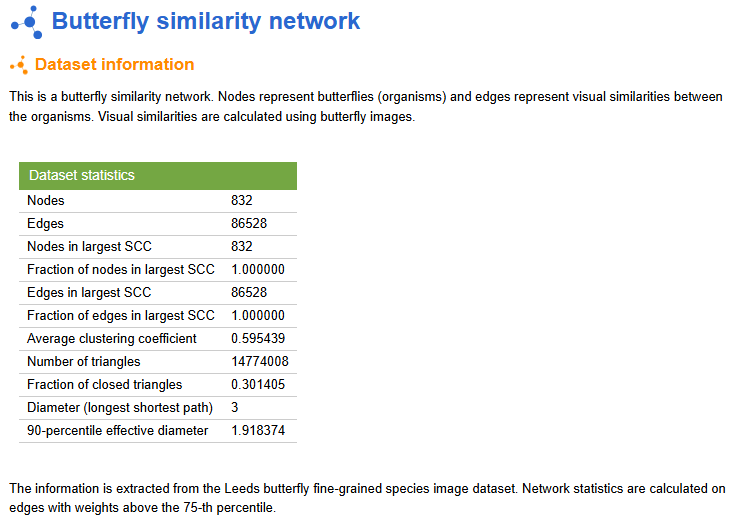

Fig. 1: Apparently true properties

```r
# Load data
butterfly_weights <- read.table(gzfile("SS-Butterfly_weights.tsv.gz"))
butterfly_names <- read.table(gzfile("SS-Butterfly_labels.tsv.gz"))

# Number of nodes
c(butterfly_weights$V1, butterfly_weights$V2) %>% unique() %>% length()
```

```
## [1] 832
```

```r
# Number of edges
nrow(butterfly_weights)
```

```
## [1] 86528
```

```r
# Finding the number of strongly connected components
graph_1 <- igraph::graph_from_data_frame(butterfly_weights[,c(1,2)], directed = FALSE)
igraph::components(graph_1, mode="strong")$membership %>% unique() %>% length()
```

```
## [1] 1
```

Now we obtain the average clustering coefficient (which matches with the website), and the number of triangles, which does not match. The website suggests that there are over 14 million triangles, but even if we count all the triangles for every node and sum them up (triple-counting all triangles), we only achieve about 13 million triangles/triples. In turn, we achieve a different fraction of closed triangles. Also the diameter is different. We also find that all nodes are connected by a path with a most 4 nodes, and so it makes sense that the 90-percentile effective diameter is very low, although the corresponding value on the website is slightly lower (1.918374). Regarding the “number of triangles”, we will conclude that the website is too unspecific to warrant further investigation.

```r
# Average clustering coefficient
igraph::transitivity(graph_1, type="average")
```

```
## [1] 0.5954394
```

```r
# Number of triangles
igraph::count_triangles(graph_1) %>% sum()
```

```
## [1] 13358898
```

```r
# Fraction of closed triangles
igraph::transitivity(graph_1, type="global")
```

```
## [1] 0.5641441
```

```r
# Diameter
igraph::diameter(graph_1)
```

```
## [1] 4
```

```r
# 90 percentile effective diameter
sp_lengths <- igraph::distances(graph_1)
quantile(sp_lengths, 0.9)
```

```
## 90%
##   2
```

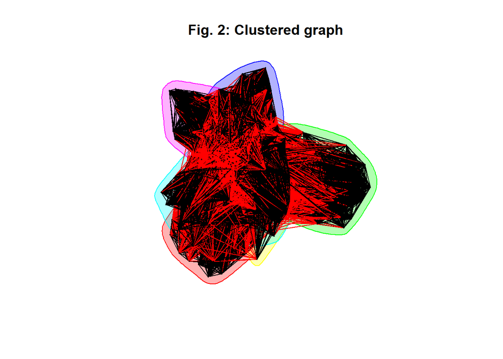

```r
# Perform louvain clustering and then plot the graph
louvain <- igraph::cluster_louvain(graph_1, resolution = 1.1)
plot(louvain, graph_1, vertex.size = 1, vertex.label = NA,
     layout = layout_with_fr(graph_1),
     main="Fig. 2: Clustered graph")
```

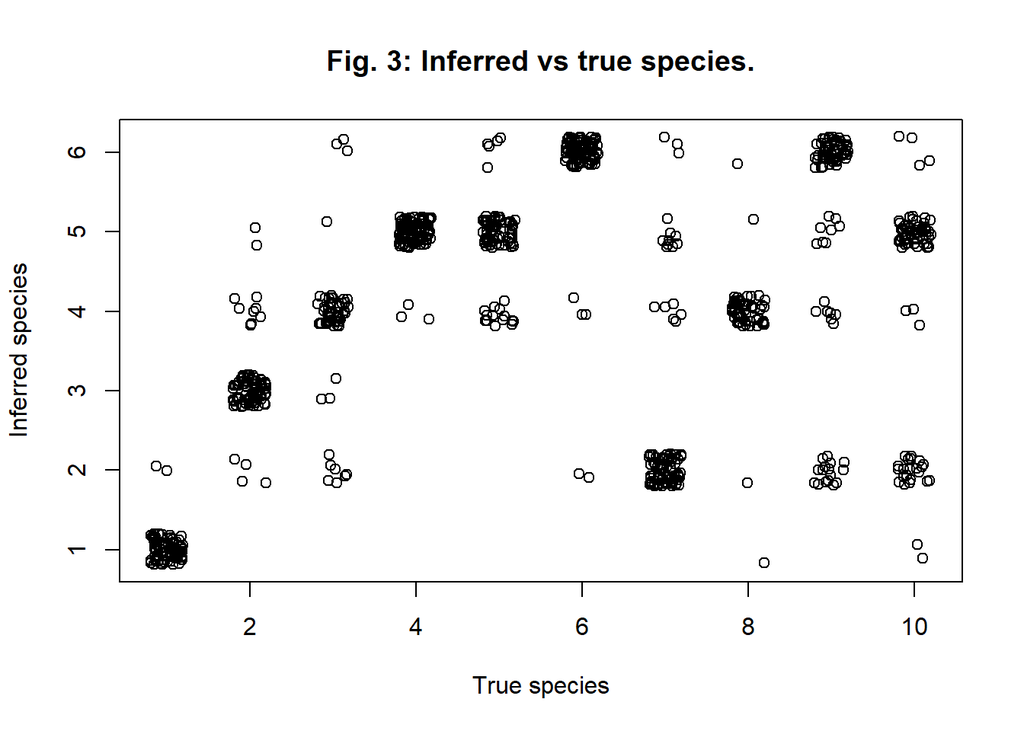

```r
plot(y = jitter(louvain$membership), x=jitter(butterfly_names$V2),
     main="Fig. 3: Inferred vs true species.",
     xlab="True species",
     ylab="Inferred species")
```

# Question 2

Recreate one of the three analyses that can be found on https://strimmerlab.github.io/ software/genenet/index.html. Document and discuss all your steps. In the analyses there is the step where you select the edges to keep. There a particular criterion is chosen for edge inclusion. Vary this criterion and explore how the resulting clusters will differ with the changes. Take one found cluster, identify the elements in it and try to find information on this cluster. Is it related to some known biological phenomena? If you do not find anything, then document your search attempts.

## Analysis chosen: E.coli

```r
#Loading the package
library("GeneNet")
```

```r
library("Rgraphviz")
#BiocManager::install("org.EcK12.eg.db")
library(org.EcK12.eg.db)
#Loading the ecoli-data
data(ecoli)
#Displaying 9 observations as time points with 102 genes.
dim(ecoli)
```

```
## [1]   9 102
```

```r
#Using shrinkage estimator to produce a matrix of partial correlation between genes
pc = ggm.estimate.pcor(ecoli)
```

```
## Estimating optimal shrinkage intensity lambda (correlation matrix): 0.1804
```

```r
#The covariance matrix of 102 genes
dim(pc)
```

```
## [1] 102 102
```

```r
#Estimating q-values (fdr = TRUE) and additional statistics (direct = TRUE)
ecoli.edges = network.test.edges(pc, direct=TRUE, fdr=TRUE)
```

```
## Estimate (local) false discovery rates (partial correlations):
## Step 1... determine cutoff point
## Step 2... estimate parameters of null distribution and eta0
## Step 3... compute p-values and estimate empirical PDF/CDF
## Step 4... compute q-values and local fdr
## Step 5... prepare for plotting
```

```
##
## Estimate (local) false discovery rates (log ratio of spvars):
## Step 1... determine cutoff point
## Step 2... estimate parameters of null distribution and eta0
## Step 3... compute p-values and estimate empirical PDF/CDF
## Step 4... compute q-values and local fdr
## Step 5... prepare for plotting
```

```r
#With 102 genes, we have 5151 potenial pairings of genes, meaning 5151 edges in the network
dim(ecoli.edges)
```

```
## [1] 5151   10
```

### FDR cutoff 0.2

```r
ecoli.net = extract.network(ecoli.edges)
```

```
##
## Significant edges:  125
##     Corresponding to  2.43 %  of possible edges
##
## Significant directions:  377
##     Corresponding to  7.32 %  of possible directions
## Significant directions in the network:  17
##     Corresponding to  13.6 %  of possible directions in the network
```

```r
node.labels = colnames(ecoli)
gr = network.make.graph(ecoli.net, node.labels, drop.singles=TRUE)
table(  edge.info(gr)$dir )
```

```
##
## forward    none
##      17     108
```

```r
sort( node.degree(gr), decreasing=TRUE)
```

```
##  sucA  fixC  cspG  ygcE  asnA  yceP  yheI b1191  eutG  lacZ  lacA  pspA  yfaD
##    18    14    10    10     9     9     9     8     8     8     7     7     7
##  cspA  lacY  yaeM  yedE b1583  ycgX  aceB  atpD  atpG  dnaG  dnaK  mopB  pspB
##     6     6     6     6     5     5     4     4     4     4     4     4     4
##  tnaA b1963  ibpB  icdA  nuoM  ygbD  yhfV  yhgI  cchB  flgD  folK  grpE  hupB
##     4     3     3     3     3     3     3     3     2     2     2     2     2
##  manX  nmpC  pspC  sodA  yecO  yfiA  yhdM  yrfH  aceA  atpH  dnaJ  ftsJ  gatC
##     2     2     2     2     2     2     2     2     1     1     1     1     1
##  gatD  gatZ  gltA  lpdA  nuoA  ompT  sucD  yjbO
##     1     1     1     1     1     1     1     1
```

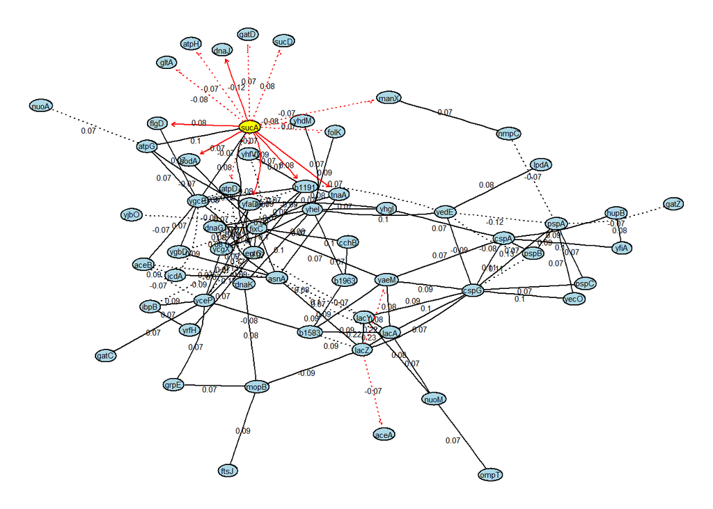

```r
#' Set node and edge attributes for more beautiful graph plotting:
globalAttrs = list()
globalAttrs$edge = list(color = "black", lty = "solid", lwd = 1, arrowsize=1)
globalAttrs$node = list(fillcolor = "lightblue", shape = "ellipse", fixedsize = FALSE)

nodeAttrs = list()
nodeAttrs$fillcolor = c('sucA' = "yellow")

edi = edge.info(gr)
edgeAttrs = list()
edgeAttrs$dir = edi$dir # set edge directions
edgeAttrs$lty = ifelse(edi$weight < 0, "dotted", "solid") # negative correlation -> dotted
edgeAttrs$color = ifelse(edi$dir == "none", "black", "red")
edgeAttrs$label = round(edi$weight, 2) # use partial correlation as edge labels

#+ fig.width=8, fig.height=7
plot(gr, attrs = globalAttrs, nodeAttrs = nodeAttrs, edgeAttrs = edgeAttrs, "fdp")
```

```r
cluster_desc <- select(org.EcK12.eg.db, keys = c("sucA", "atpC", "sodA", "gltA", "dnaJ", "gatD", "atpH", "sucD", "flgD", "manX"), columns = "GENENAME", keytype = "ALIAS")
```

The cluster has multiple genes which plays a part in ATP synthesis and citric acid cycle.

### FDR cutoff 0.1

```r
ecoli.net = extract.network(ecoli.edges, cutoff.ggm=0.9, cutoff.dir=0.9)
```

```
##
## Significant edges:  65
##     Corresponding to  1.26 %  of possible edges
##
## Significant directions:  269
##     Corresponding to  5.22 %  of possible directions
## Significant directions in the network:  6
##     Corresponding to  9.23 %  of possible directions in the network
```

```r
node.labels = colnames(ecoli)
gr = network.make.graph(ecoli.net, node.labels, drop.singles=TRUE)
table(  edge.info(gr)$dir )
```

```
##
## forward    none
##       6      59
```

```r
sort( node.degree(gr), decreasing=TRUE)
```

```
##  sucA  cspG  fixC  yheI  lacA  lacY  asnA  eutG  lacZ  yceP  yedE  ygcE b1583
##    10     8     7     7     6     6     5     5     5     5     5     5     3
##  cspA  icdA  pspA  pspB  ycgX  yfaD  atpD b1191  dnaG  hupB  ibpB  mopB  tnaA
##     3     3     3     3     3     3     2     2     2     2     2     2     2
##  yaeM  yfiA  aceB  atpG b1963  cchB  dnaJ  dnaK  flgD  folK  ftsJ  gltA  lpdA
##     2     2     1     1     1     1     1     1     1     1     1     1     1
##  nuoM  sucD  yecO  ygbD  yhdM  yjbO
##     1     1     1     1     1     1
```

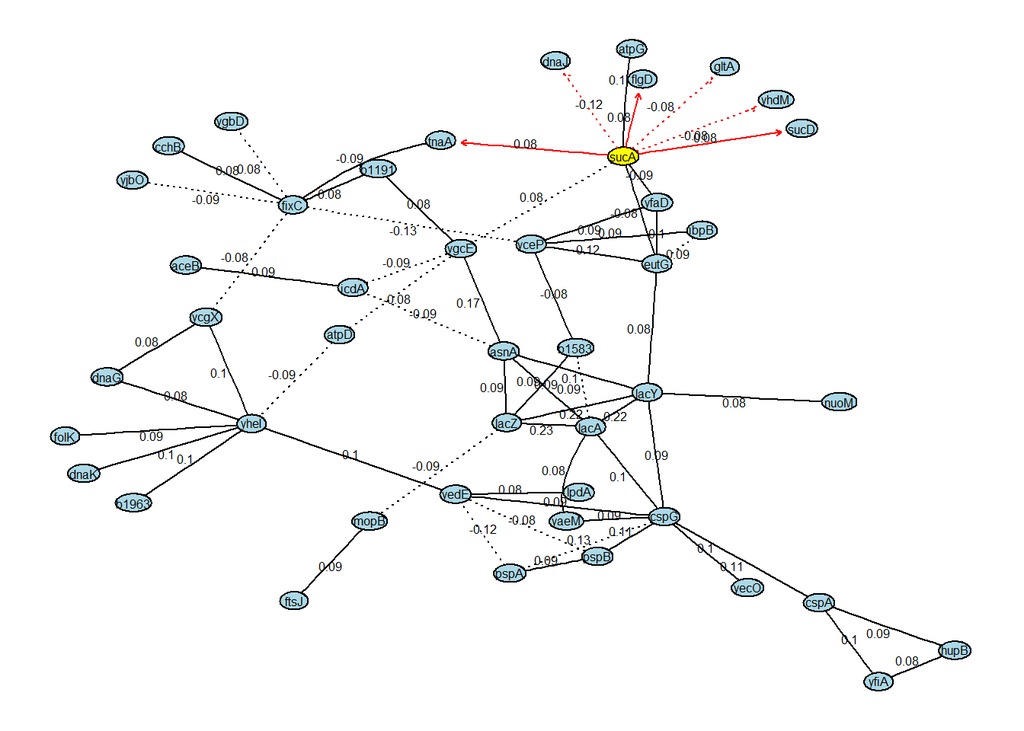

```r
#' Set node and edge attributes for more beautiful graph plotting:
globalAttrs = list()
globalAttrs$edge = list(color = "black", lty = "solid", lwd = 1, arrowsize=1)
globalAttrs$node = list(fillcolor = "lightblue", shape = "ellipse", fixedsize = FALSE)

nodeAttrs = list()
nodeAttrs$fillcolor = c('sucA' = "yellow")

edi = edge.info(gr)
edgeAttrs = list()
edgeAttrs$dir = edi$dir # set edge directions
edgeAttrs$lty = ifelse(edi$weight < 0, "dotted", "solid") # negative correlation -> dotted
edgeAttrs$color = ifelse(edi$dir == "none", "black", "red")
edgeAttrs$label = round(edi$weight, 2) # use partial correlation as edge labels

#+ fig.width=8, fig.height=7
plot(gr, attrs = globalAttrs, nodeAttrs = nodeAttrs, edgeAttrs = edgeAttrs, "fdp")
```

```r
select(org.EcK12.eg.db, keys = c("sucA", "tnaA", "flgD", "sucD", "gltA", "atpG", "yhdM", "dnaJ", "yfaD"), columns = "GENENAME", keytype = "ALIAS")
```

```
##   ALIAS                                                    GENENAME
## 1  sucA  subunit of E1(0) component of 2-oxoglutarate dehydrogenase
## 2  tnaA                                               tryptophanase
## 3  flgD         flagellar biosynthesis, initiation of hook assembly
## 4  sucD                       succinyl-CoA synthetase subunit alpha
## 5  gltA                                            citrate synthase
## 6  atpG                       ATP synthase F1 complex subunit gamma
## 7  yhdM                  DNA-binding transcriptional activator ZntR
## 8  dnaJ                                      chaperone protein DnaJ
## 9  yfaD inactive recombination-promoting nuclease-like protein RpnE
```

```r
select(org.EcK12.eg.db, keys = c("yheI", "ycgX","dnaG","folK","dnaK","b1963","yedE","atpD"), columns = "GENENAME", keytype = "ALIAS")
```

```
##   ALIAS                                                          GENENAME
## 1  yheI                             Type II secretion system protein GspJ
## 2  ycgX                            DUF1398 domain-containing protein YcgX
## 3  dnaG                                                       DNA primase
## 4  folK 2-amino-4-hydroxy-6-hydroxymethyldihydropteridine diphosphokinase
## 5  dnaK                                            chaperone protein DnaK
## 6 b1963                                                              <NA>
## 7  yedE                                putative selenium transporter YedE
## 8  atpD                              ATP synthase F1 complex subunit beta
```

The first cluster is similar to the 0.2-cutoff and has multiple genes which plays a part in APT synthesis and citric acid cycle.

The second cluster does not seem to be related to any obvious common biological phenomenon.

### 70 stronges edges

```r
ecoli.net = extract.network(ecoli.edges, method.ggm="number", cutoff.ggm=70)
```

```
##
## Significant edges:  70
##     Corresponding to  1.36 %  of possible edges
##
## Significant directions:  377
##     Corresponding to  7.32 %  of possible directions
## Significant directions in the network:  9
##     Corresponding to  12.86 %  of possible directions in the network
```

```r
node.labels = colnames(ecoli)
gr = network.make.graph(ecoli.net, node.labels, drop.singles=TRUE)
table(  edge.info(gr)$dir )
```

```
##
## forward    none
##       9      61
```

```r
sort( node.degree(gr), decreasing=TRUE)
```

```
##  sucA  cspG  fixC  yheI  lacA  lacY  lacZ  asnA  eutG  yceP  yedE  ygcE  pspA
##    11     8     7     7     6     6     6     5     5     5     5     5     4
##  atpD b1191 b1583  cspA  icdA  mopB  pspB  tnaA  yaeM  ycgX  yfaD  dnaG  dnaK
##     3     3     3     3     3     3     3     3     3     3     3     2     2
##  hupB  ibpB  yfiA  aceB  atpG b1963  cchB  dnaJ  flgD  folK  ftsJ  gltA  lpdA
##     2     2     2     1     1     1     1     1     1     1     1     1     1
##  nmpC  nuoM  sucD  yecO  ygbD  yhdM  yjbO
##     1     1     1     1     1     1     1
```

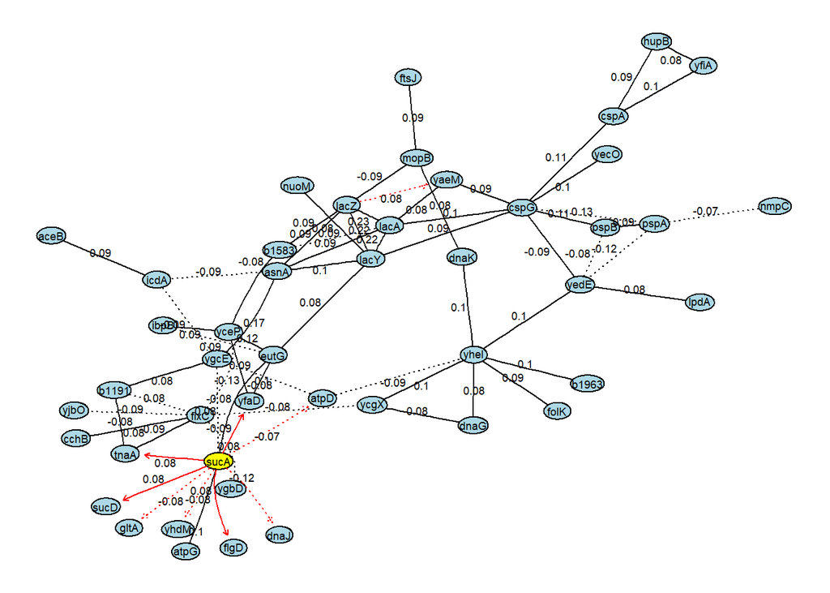

```r
#' Set node and edge attributes for more beautiful graph plotting:
globalAttrs = list()
globalAttrs$edge = list(color = "black", lty = "solid", lwd = 1, arrowsize=1)
globalAttrs$node = list(fillcolor = "lightblue", shape = "ellipse", fixedsize = FALSE)

nodeAttrs = list()
nodeAttrs$fillcolor = c('sucA' = "yellow")

edi = edge.info(gr)
edgeAttrs = list()
edgeAttrs$dir = edi$dir # set edge directions
edgeAttrs$lty = ifelse(edi$weight < 0, "dotted", "solid") # negative correlation -> dotted
edgeAttrs$color = ifelse(edi$dir == "none", "black", "red")
edgeAttrs$label = round(edi$weight, 2) # use partial correlation as edge labels

#+ fig.width=8, fig.height=7
plot(gr, attrs = globalAttrs, nodeAttrs = nodeAttrs, edgeAttrs = edgeAttrs, "fdp")
```

```r
select(org.EcK12.eg.db, keys = c("sucA", "ygcE","sucD","atpG","dnaJ","gltA","flgD","yhdM","yfaD","fnaA"), columns = "GENENAME", keytype = "ALIAS")
```

```
##    ALIAS                                                    GENENAME
## 1   sucA  subunit of E1(0) component of 2-oxoglutarate dehydrogenase
## 2   ygcE                                  putative sugar kinase YgcE
## 3   sucD                       succinyl-CoA synthetase subunit alpha
## 4   atpG                       ATP synthase F1 complex subunit gamma
## 5   dnaJ                                      chaperone protein DnaJ
## 6   gltA                                            citrate synthase
## 7   flgD         flagellar biosynthesis, initiation of hook assembly
## 8   yhdM                  DNA-binding transcriptional activator ZntR
## 9   yfaD inactive recombination-promoting nuclease-like protein RpnE
## 10  fnaA                                                        <NA>
```

The cluster is similar to the 0.2-cutoff and 0.1-cutoff and has multiple genes which plays a part in APT synthesis and citric acid cycle.